# Data preparation

Natasa Mortvanski

Universitat Pompeu Fabra  
natasa.mortvanski01@estudiant.upf.edu

2023-02-21

This document contains the code for data preparation (loading different alpha metrics, filtering of the samples and columns of interest) of American Gut Project data that is going to be used as healthy control in this Master thesis, as well as data from various studies of different pathological conditions supposedly affecting gut microbiome alpha diversity.

# Healthy data preprocessing

Loading necessary libraries:

```r
library(dplyr)
```

```r
#install.packages('purrr')
library(purrr)
library(tibble)
library(ggplot2)
library(stringr)
library(RColorBrewer)
library(gridExtra)
library(grid)
```

### About dataset:

As a source of samples for healthy control we chose American Gut Project study. Data and metadata are available on Qiita platform:

1. Subset of the American Gut Project dataset (healthy dataset) -> [dataset link](https://qiita.ucsd.edu/study/description/10317)

Loading the metadata file for AGP study samples:

```r
AGP_metadata <- read.delim("~/Desktop/master_project/Master-Project-Natasa-Mortvanski/00_raw_data/01_AGP_data/10317_20221012-092710.txt.gz")
#colnames(AGP_metadata)

nrow(AGP_metadata)
```

```
## [1] 37867
```

Loading tables containing different alpha diversity metrics:

```r
shannon_AGP <- read.delim("~/Desktop/master_project/Master-Project-Natasa-Mortvanski/00_raw_data/01_AGP_data/shannon_AGP_all.tsv.gz")
chao1_AGP <- read.delim("~/Desktop/master_project/Master-Project-Natasa-Mortvanski/00_raw_data/01_AGP_data/chao1_AGP_all.tsv.gz")
menhinick_AGP <- read.delim("~/Desktop/master_project/Master-Project-Natasa-Mortvanski/00_raw_data/01_AGP_data/menhinick_AGP_all.tsv.gz")
margalef_AGP <- read.delim("~/Desktop/master_project/Master-Project-Natasa-Mortvanski/00_raw_data/01_AGP_data/margalef_AGP_all.tsv.gz")
simpson_AGP <- read.delim("~/Desktop/master_project/Master-Project-Natasa-Mortvanski/00_raw_data/01_AGP_data/simpson_AGP_all.tsv.gz")
fisher_AGP <- read.delim("~/Desktop/master_project/Master-Project-Natasa-Mortvanski/00_raw_data/01_AGP_data/fisher_AGP_all.tsv.gz")
gini_AGP <- read.delim("~/Desktop/master_project/Master-Project-Natasa-Mortvanski/00_raw_data/01_AGP_data/gini_AGP_all.tsv.gz")
strong_AGP <- read.delim("~/Desktop/master_project/Master-Project-Natasa-Mortvanski/00_raw_data/01_AGP_data/strong_AGP_all.tsv.gz")
faith_AGP <- read.delim("~/Desktop/master_project/Master-Project-Natasa-Mortvanski/00_raw_data/01_AGP_data/faith_AGP_all.tsv.gz")
pielou_AGP <- read.delim("~/Desktop/master_project/Master-Project-Natasa-Mortvanski/00_raw_data/01_AGP_data/pielou_AGP_all.tsv.gz")

# Make inverse Simpson
#simpson_AGP$inverse_simpson <- sapply(simpson_AGP$simpson, function(x) 1/x)

names(faith_AGP)[names(faith_AGP) == 'X.SampleID'] <- 'X'

# Merge all alpha diversity tables
all_alpha <- list(shannon_AGP, chao1_AGP, menhinick_AGP, margalef_AGP, fisher_AGP, gini_AGP, strong_AGP, simpson_AGP, faith_AGP, pielou_AGP)

all_alpha <- all_alpha %>% reduce(inner_join, by="X")
names(all_alpha)[names(all_alpha) == 'X'] <- 'sample_id'

nrow(all_alpha)
```

```
## [1] 10399
```

Totall number of samples in this dataset is 10399.

Now lets combine alpha metrics and metadata in the same dataframe (`AGP`):

```r
# Merge all_alpha and AGP_metadata
AGP <- all_alpha %>% left_join(AGP_metadata, by=c('sample_id' = 'sample_name'))

# Replace NA with empty string
AGP <- replace(AGP, is.na(AGP), "")

nrow(AGP)
```

```
## [1] 10399
```

We are left with 10399 samples for which alpha metrics were calculated.  
Lets filter out samples that are truly healthy:

```r
# Filter samples by age (only adult samples)
AGP_healthy_subset <- AGP %>%
  filter(age_cat== "20s" |
         age_cat== "30s" |
         age_cat== "40s" |
         age_cat== "50s" |
         age_cat== "60s")

# Filter out stool and feces samples
AGP_healthy_subset <- AGP_healthy_subset %>%
  filter(sample_type=="feces" |
         sample_type=="Stool")

#Keep only samples with normal BMI
AGP_healthy_subset <- AGP_healthy_subset %>%
  filter(host_body_mass_index > 18.5 &
         host_body_mass_index < 25)

# Filtering criteria No. 1
## Include only samples that have reported not having any of the following diseases
AGP_healthy_subset_1 <- AGP_healthy_subset %>%
  filter(antibiotic_history=="I have not taken antibiotics in the past year." &
         diabetes=="I do not have this condition" &
         ibd=="I do not have this condition" &
         ibs=="I do not have this condition" &
         cdiff=="I do not have this condition" &
         cancer=="I do not have this condition" &
         mental_illness=="No" &
         mental_illness_type_substance_abuse=="false" &
         mental_illness_type_depression=="false" &
         asd=="I do not have this condition" &
         alzheimers=="I do not have this condition" &
         add_adhd=="I do not have this condition" &
         epilepsy_or_seizure_disorder=="I do not have this condition" &
         sibo=="I do not have this condition" &   # small intestinal bacterial overgrowth
         pku =="I do not have this condition" &   # phenylketonuria
         thyroid=="I do not have this condition" &
         kidney_disease=="I do not have this condition" &
         clinical_condition=="I do not have this condition" &
         acid_reflux=="I do not have this condition" &
         autoimmune=="I do not have this condition" &
         cardiovascular_disease=="I do not have this condition" &
         lung_disease =="I do not have this condition" &
         liver_disease =="I do not have this condition")

# Filtering criteria No. 2
## Other solution is to apply only filters used in original AGP study:
AGP_healthy_subset_2 <- AGP_healthy_subset %>%
  filter(antibiotic_history=="I have not taken antibiotics in the past year." &
         diabetes=="I do not have this condition" &
         ibd=="I do not have this condition")

# Filtering criteria No. 3
## AGP filters + no IBS or Cdiff
AGP_healthy_subset_3 <- AGP_healthy_subset %>%
  filter(antibiotic_history=="I have not taken antibiotics in the past year." &
         diabetes=="I do not have this condition" &
         ibd=="I do not have this condition" &
         ibs=="I do not have this condition" &
         cdiff=="I do not have this condition")

# Number of samples without any reported clinical condition
nrow(AGP_healthy_subset_1)  #861
```

```
## [1] 600
```

```r
# Number of samples after filtering only by criteria reported by AGP paper
nrow(AGP_healthy_subset_2)  #3275
```

```
## [1] 2292
```

```r
# Number of samples after filtering only by criteria reported by AGP paper + without IBS and Cdiff
nrow(AGP_healthy_subset_3)  #2145
```

```
## [1] 1465
```

Lets see if there is a difference in values of alpha diversity metrics in different subsets:

```r
# make tables of summaries of all 4 subsets of AGP data
tabs <- list()
subsets <- list(AGP_healthy_subset, AGP_healthy_subset_1, AGP_healthy_subset_2, AGP_healthy_subset_3)

for(x in 1:length(subsets)){
tabs[[x]] <- subsets[[x]] %>%
  summarise(shannon_entropy,
            chao1,
            menhinick,
            margalef,
            simpson,
            pielou_evenness,
            #inverse_simpson,
            fisher_alpha,
            gini_index,
            strong,
            faith_pd) %>%
  broom::tidy()
}
# Extract minimums, means and maximums of each metric and combine them in new tables
cols <- c("column", "mean", "min", "max")
metric <- c("shannon_entropy", "chao1", "menhinick", "margalef", "fisher_alpha", "simpson", "gini_index", "strong", "pielou_evenness", "faith_pd" )
alpha_tables <- list()

for (i in 1:length(metric)){
  alpha_tables[[i]] <- tibble()
  for (x in tabs){
    alpha_tables[[i]] <- bind_rows(alpha_tables[[i]], filter(x, column == metric[[i]]))
  }
  alpha_tables[[i]] <- alpha_tables[[i]][, names(alpha_tables[[i]]) %in% cols]
  alpha_tables[[i]] <- alpha_tables[[i]] %>% add_column(subsample = c("AGP fecal samples of participants aged 20-69", "healthy AGP participants without any reported disease", "healthy AGP participants (AGP paper criteria)", "healthy AGP participants (AGP paper criteria + no IBD nor Cdiff)"), .before = "column")
}

all_alpha_tables<- tibble()
for(x in 1:length(alpha_tables)){
  all_alpha_tables <- bind_rows(all_alpha_tables, alpha_tables[[x]])
}
```

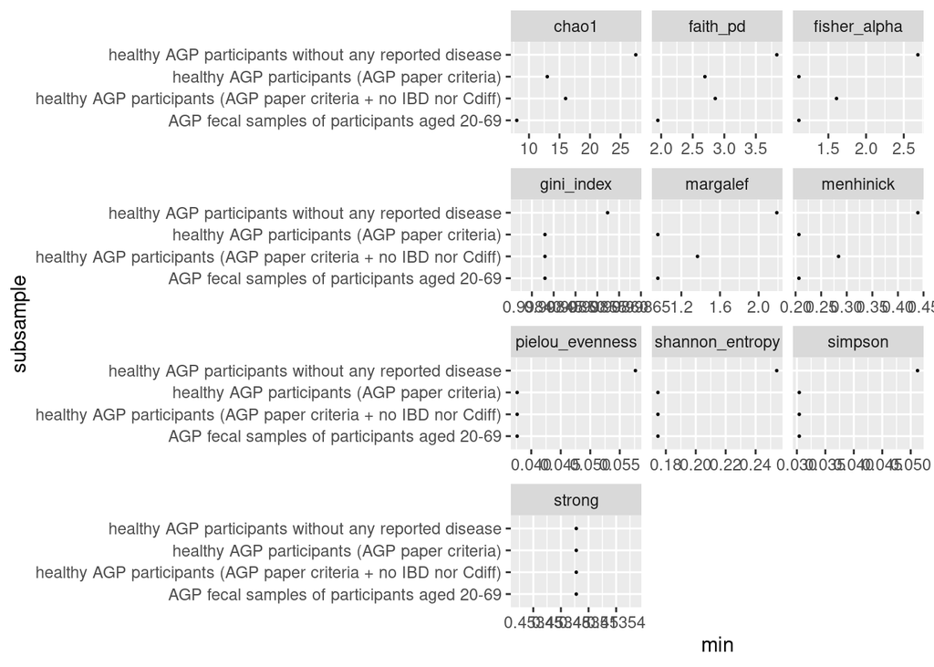

```r
# Plot values of min, mean and max for each subset of AGP data

all_alpha_tables %>%
  ggplot(aes(x= min, y=subsample)) +
  geom_dotplot(binaxis='y', stackdir='center') +
  facet_wrap(column ~ ., scales = "free_x", ncol=3)
```

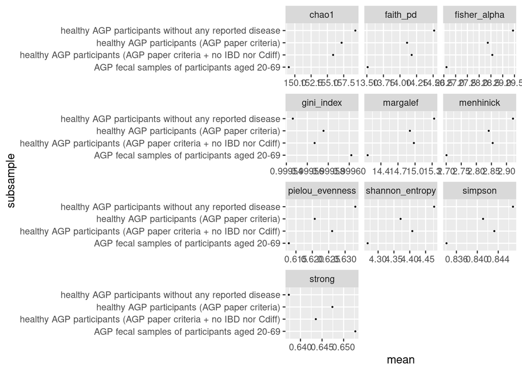

```r
all_alpha_tables %>%
  ggplot(aes(x= mean, y=subsample)) +
  geom_dotplot(binaxis='y', stackdir='center') +
  facet_wrap(column ~ ., scales = "free_x", ncol=3)
```

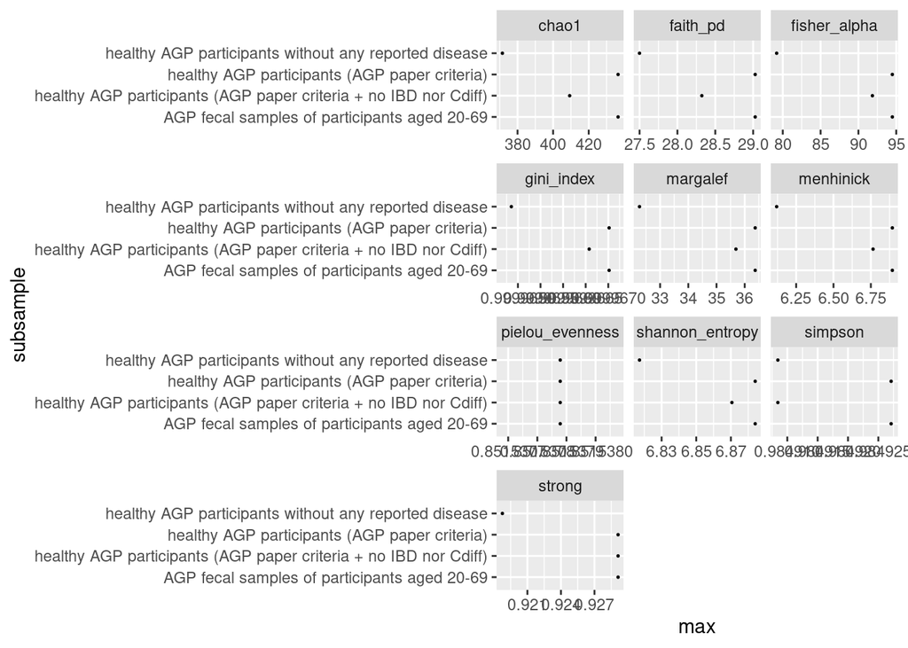

```r
all_alpha_tables %>%
  ggplot(aes(x= max, y=subsample)) +
  geom_dotplot(binaxis='y', stackdir='center') +
  facet_wrap(column ~ ., scales = "free_x", ncol=3)
```

Group of healthy AGP participants without any reported disease has the highest minimums and means of all alpha diversity indexes except from Gini’s and Strong’s that have the lowest mean.

Lets explore how distributions of different metrics change in different subsets:

Generate a vector of 10 random colors for histograms:

```r
qual_col_pals <- brewer.pal.info[brewer.pal.info$category == 'qual',]
colors <- unlist(mapply(brewer.pal, qual_col_pals$maxcolors, rownames(qual_col_pals)))
```

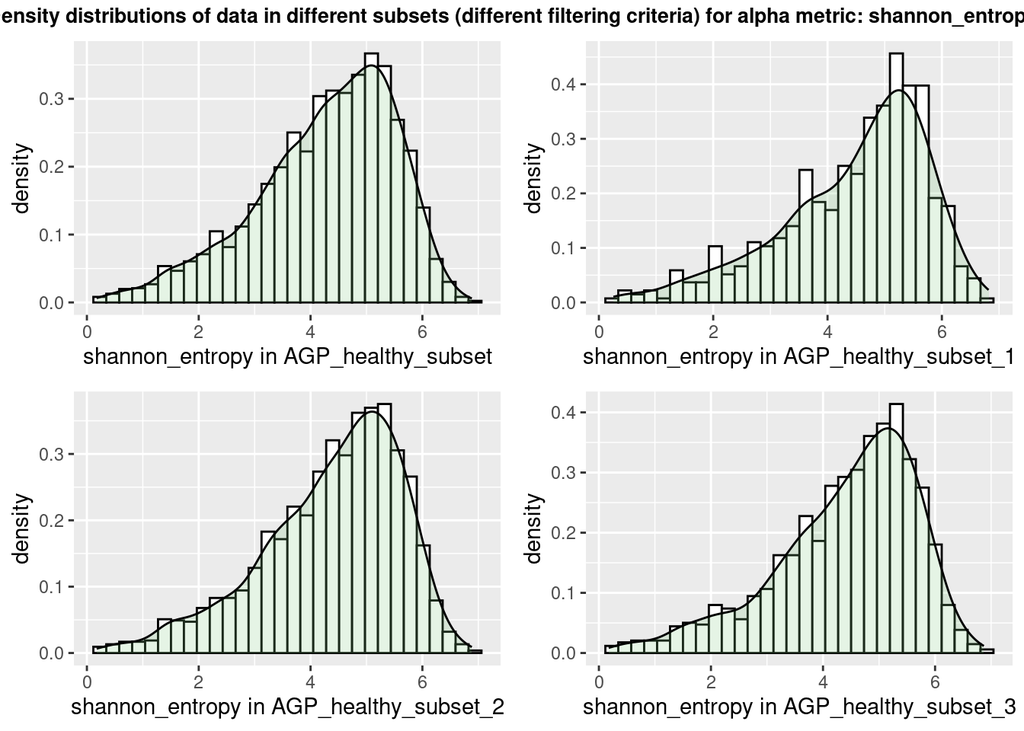

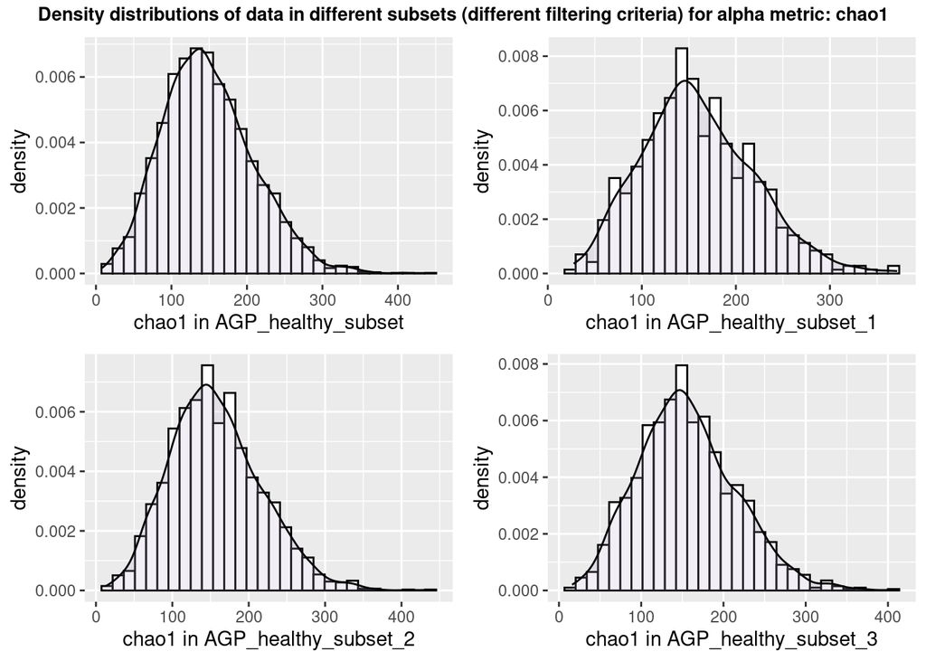

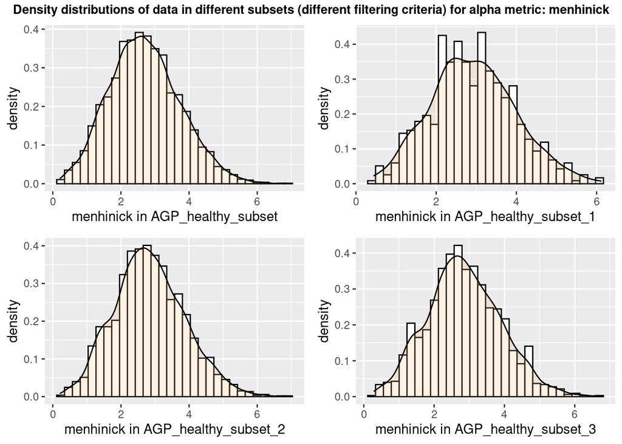

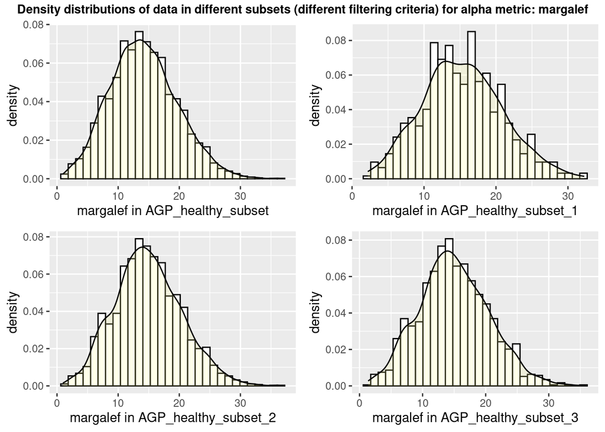

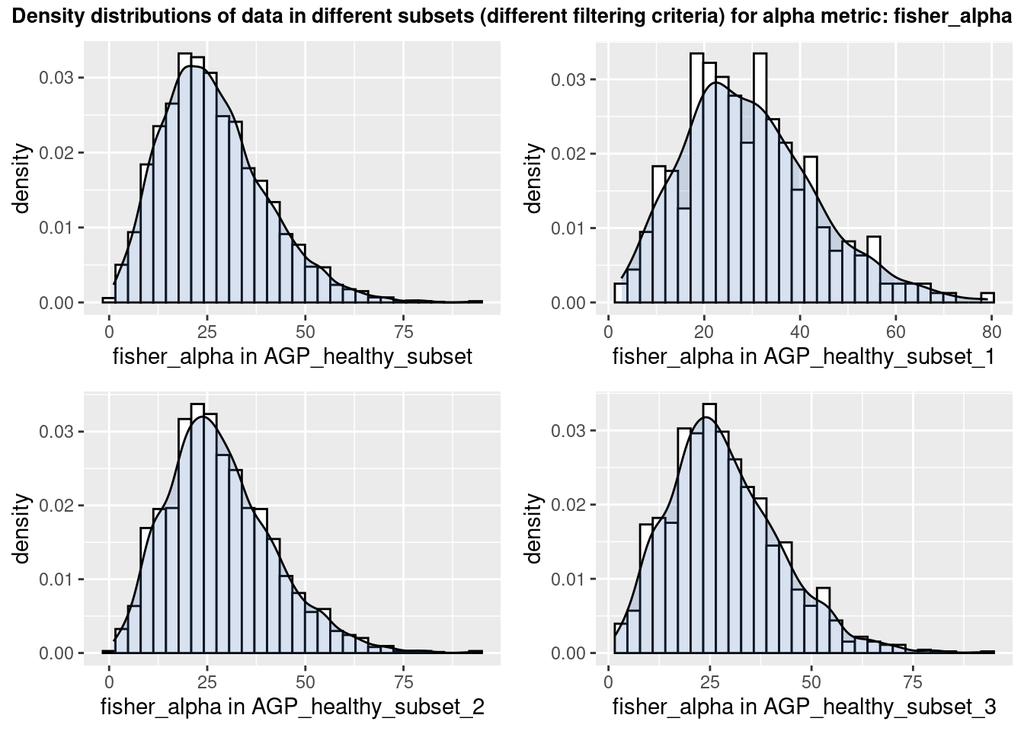

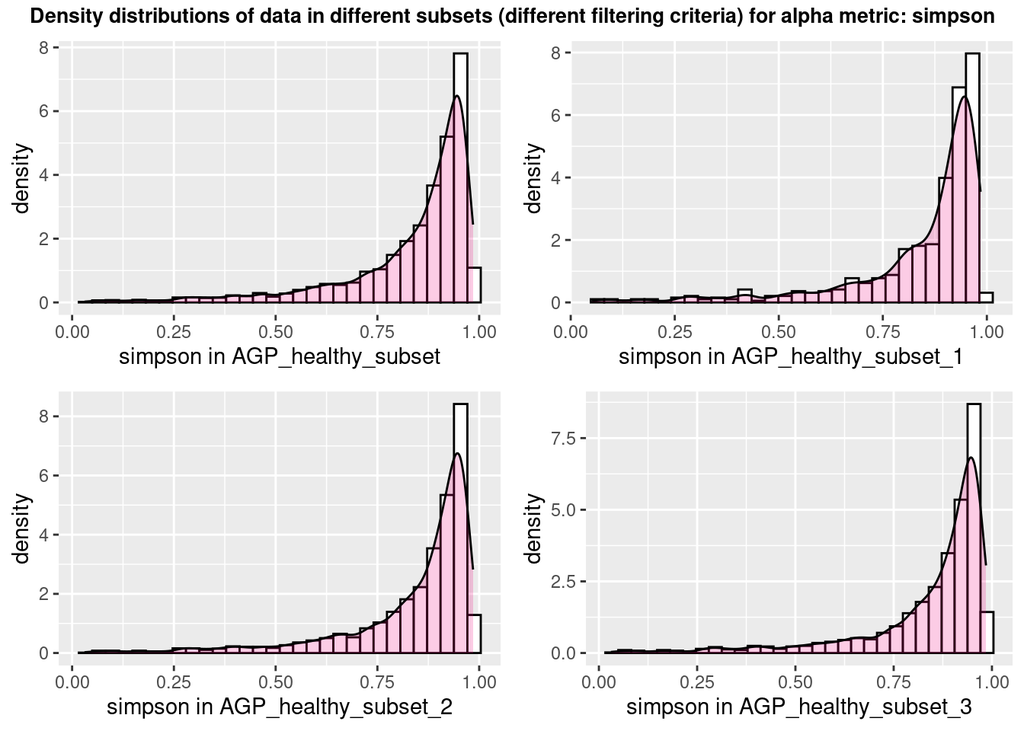

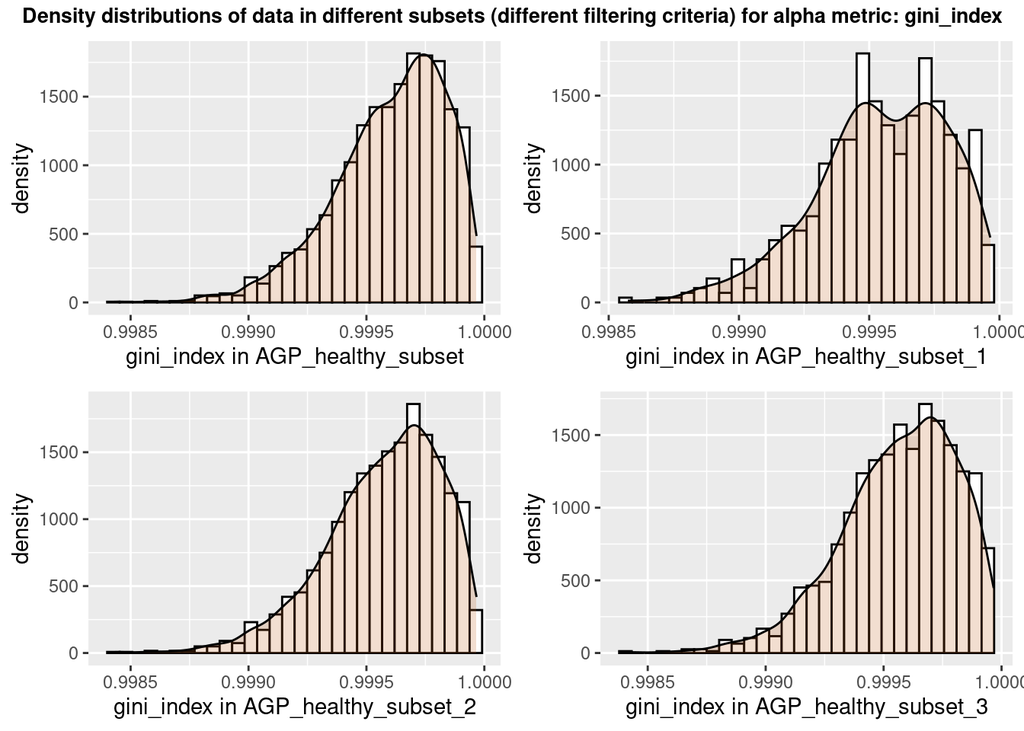

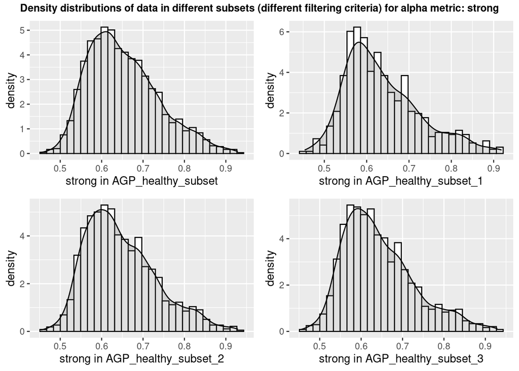

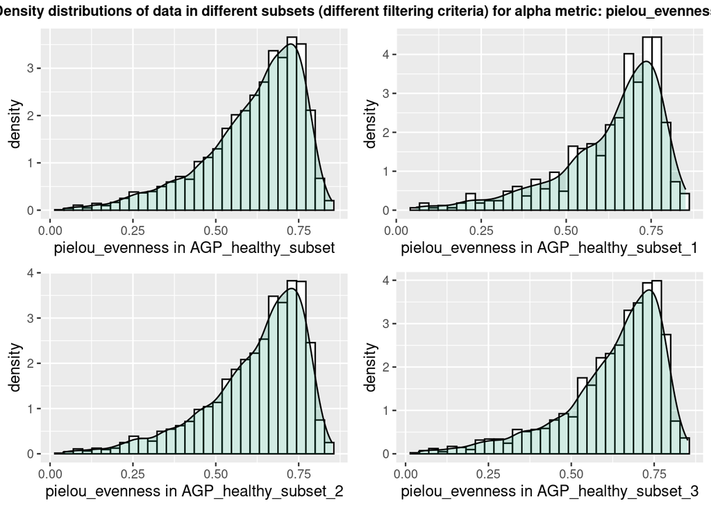

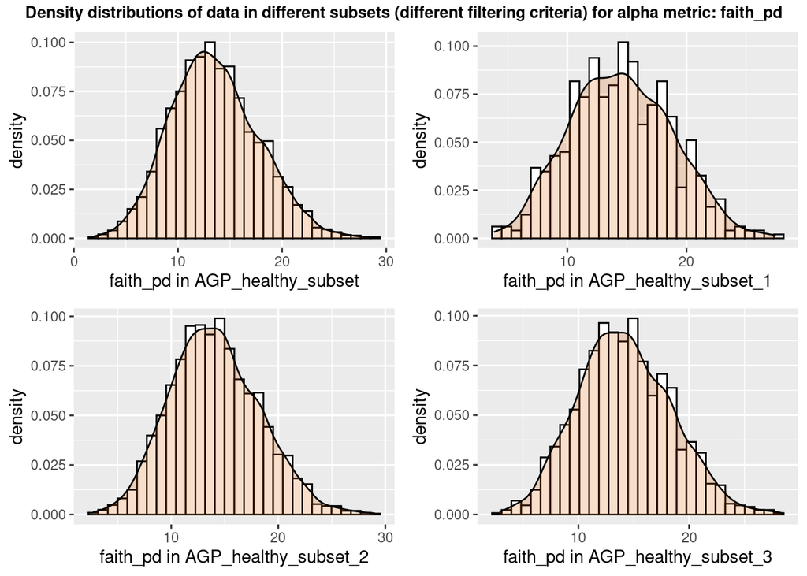

```r
library(purrr)
subset_list <- list(AGP_healthy_subset, AGP_healthy_subset_1, AGP_healthy_subset_2, AGP_healthy_subset_3)
subset_names <- c("AGP_healthy_subset", "AGP_healthy_subset_1", "AGP_healthy_subset_2", "AGP_healthy_subset_3")
subset_list <- setNames(subset_list, subset_names)

histo <- vector('list', length(subset_list)*length(metric))

for (i in 1:length(metric)){
  for (j in 1:length(subset_list)){
    histo[[i]][[j]] <- subset_list[[j]] %>% ggplot(aes(x = .data[[metric[i]]])) +
      geom_histogram(aes(y=..density..), colour="black", fill="white", bins=30)+
      geom_density(alpha=.2, fill=colors[i]) +
      xlab(label = paste(metric[i], names(subset_list[j]), sep=' in ')) +
      ylab(label ="density")
  }
}

plot_list <- list()
for (i in 1:length(metric)){
  plot_list[[i]] <- list()
  for (j in 1:length(subset_list)){
    plot_list[[i]][[j]] <- histo[[i]][[j]]
  }
}


for (i in 1:length(metric)){
  grid.arrange(grobs = plot_list[[i]], ncol=2, top = textGrob(paste ("Density distributions of data in different subsets (different filtering criteria) for alpha metric:", metric[i], sep =" "), gp=gpar(fontsize=10,font=2)))
}
```

For now lets use the subset of healthy samples after most restrictive filtering (healthy AGP participants without any reported disease):

```r
AGP_healthy_subset <- AGP_healthy_subset_1

nrow(AGP_healthy_subset)
```

```
## [1] 600
```

There is 600 healthy samples.

One of the things we are interested in is the nutrition of study participants. AGP supposedly incorporates data from Vioscreen questionaire about nutrition habits. Let’s examine those columns:

```r
# Examine Vioscreen data columns
cols <- grep("^vioscreen.?", names(AGP_healthy_subset), value=T)

# Show unique values in each of the vioscreen columns
#lapply(AGP_healthy_subset[,cols], unique)
```

Vioscreen columns are highly redundand (empty). Furthermore, only available values for vioscreen columns are: “” and “not applicable”. We can delete vioscreen columns from the table AGP_healthy_subset because they are not informative:

```r
# Delete vioscreen columns
AGP_healthy_subset <- AGP_healthy_subset[, !names(AGP_healthy_subset) %in% cols]
```

Delete columns that are not informative enough, for example mostly empty, mostly consisting of ‘Unspecified’ answer or uniform (only have one category, so useless for comparisons):

```r
# Delete almost empty columns (missing more than 90% of the samples)
empty_columns <- colSums(is.na(AGP_healthy_subset) | AGP_healthy_subset == "") > nrow(AGP_healthy_subset)*0.9
AGP_healthy_subset <- AGP_healthy_subset[, !names(AGP_healthy_subset) %in% empty_columns]

# Delete columns that have more than 80% Uncpecified answers
unspec_columns <- colSums(AGP_healthy_subset == "Unspecified" | AGP_healthy_subset == "") > nrow(AGP_healthy_subset)*0.8
AGP_healthy_subset <- AGP_healthy_subset[, !unspec_columns]

#Delete columns with uniform values (all values are the same)
uniform_columns <- vapply(AGP_healthy_subset, function(x) length(unique(x)) == 1, logical(1L))
AGP_healthy_subset <- AGP_healthy_subset[, !uniform_columns]
```

Furthermore, we are not interested in examining effects of Covid or surfing on gut microbiome so we are going to delete these columns:

```r
# Delete covid related columns
cols <- grep("^covid?", names(AGP_healthy_subset), value=T)
AGP_healthy_subset <- AGP_healthy_subset[, !names(AGP_healthy_subset) %in% cols]

# Delete columns related to surfing data
cols <- grep("^surf_.?", names(AGP_healthy_subset), value=T)
AGP_healthy_subset <- AGP_healthy_subset[, !names(AGP_healthy_subset) %in% cols]
```

Other redundand columns:

- host_age_units - in years for all samples
- host_age_normalized_years is the same as host_age,
- host_subject_id and anonymized_name - we already have sample identifiers
- (sample_name), we don’t need subject ID since we don’t need to identify subjects
- roommates_in_study - irrelevant since we can’t identify them,
- toilet_water_access - irrelevant
- collection_timestamp - irrelevant

```r
# Delete columns
cols <- c('host_age_units', 'host_age_normalized_years', 'host_subject_id', 'roommates_in_study', 'toilet_water_access', 'anonymized_name', 'collection_timestamp')
AGP_healthy_subset <- AGP_healthy_subset[, !names(AGP_healthy_subset) %in% cols]

ncol(AGP_healthy_subset)
```

```
## [1] 194
```

```r
#colnames(AGP_healthy_subset)
```

We are left with 194 columns relating to participants’ nutrition habits, allergies, physical activity, cohabitation etc.

Check other columns of interest

```r
table(AGP_healthy_subset$sex)
```

```
##
## female   male
##    331    269
```

```r
# cathegories: female, male, other, unspecified

# Delete other and unspecified
AGP_healthy_subset <- AGP_healthy_subset %>%
  filter(sex=="female" | sex=="male")

table(AGP_healthy_subset$bmi_cat)
```

```
##
##      Normal Unspecified
##         596           4
```

```r
# cathegories: Normal, Overweight, Unspecified

# Delete Unspecified
AGP_healthy_subset <- AGP_healthy_subset %>%
  filter(bmi_cat !="Unspecified")
```

```r
nrow(AGP)
```

```
## [1] 10399
```

```r
nrow(AGP_healthy_subset)
```

```
## [1] 596
```

Export table into csv format:

```r
write.csv(AGP, gzfile("~/Desktop/master_project/Master-Project-Natasa-Mortvanski/01_tidy_data/AGP_all.csv.gz"), row.names=FALSE)
write.csv(AGP_healthy_subset, gzfile("~/Desktop/master_project/Master-Project-Natasa-Mortvanski/01_tidy_data/AGP_healthy.csv.gz"), row.names=FALSE)
```

# Disease data preprocessing

### About datasets

Following studies will be used as source of samples of different pathological conditions that affect alpha diversity:

1. Multi-omics of the gut microbial ecosystem in inflammatory bowel diseases, [dataset link](https://qiita.ucsd.edu/study/description/11484) and Metaomics Reveals Microbiome Based Proteolysis as a Driver of Ulcerative Colitis Severity, [dataset link](https://qiita.ucsd.edu/study/description/11549)

2. Guiding longitudinal sampling in inflammatory bowel diseases cohorts -> [dataset link](https://qiita.ucsd.edu/study/description/2538#)

3. Changes in Microbial Ecology after Fecal Microbiota Transplantation for recurrent C. difficile Infection Affected by Underlying Inflammatory Bowel Disease -> [dataset link](https://qiita.ucsd.edu/study/description/10057)

4. Dynamic changes in short- and long-term bacterial composition following fecal microbiota transplantation for recurrent Clostridium difficile infection -> [dataset link](https://qiita.ucsd.edu/study/description/1924)

All studies’ data and metadata is available on Qiita platform.

```r
# Prepare metadata files

# for study 1.
IBD_meta_1 <- read.delim("~/Desktop/master_project/Master-Project-Natasa-Mortvanski/00_raw_data/02_inflammatory_bowel_disease/sample_information_from_prep_4068.tsv.gz")

# for study 2.
IBD_meta_2 <- read.delim("~/Desktop/master_project/Master-Project-Natasa-Mortvanski/00_raw_data/02_inflammatory_bowel_disease/sample_information_from_prep_8715.tsv.gz")

# for study 3.
CD_2a <- read.delim("~/Desktop/master_project/Master-Project-Natasa-Mortvanski/00_raw_data/05_chrons_disease_longitudinal/sample_information_from_prep_569.tsv.gz")

# for study 4.
trans_IBD_CDI <- read.delim("~/Desktop/master_project/Master-Project-Natasa-Mortvanski/00_raw_data/03_fecal_transpl_CDI_and_IBD/sample_information_transpl_CDI_IBD.txt.gz")

# for study 5.
C_diff_tr <- read.delim("~/Desktop/master_project/Master-Project-Natasa-Mortvanski/00_raw_data/04_C_difficile/sample_information_from_prep_262.tsv.gz")


# change the name of second column in IBD_meta_1 so it matches colimn names n IBD_meta_2
names(IBD_meta_1)[names(IBD_meta_1) == 'diagnosis'] <- 'condition'
names(IBD_meta_2)[names(IBD_meta_2) == 'disease'] <- 'condition'
names(trans_IBD_CDI)[names(trans_IBD_CDI) == 'pathology'] <- 'condition'
```

## IBD datasets

Lets upload first two studies related to Inflammatory bowel disease (Ulcerative colitis and Crohn’s disease):

```r
IBD_meta_1 <- select(IBD_meta_1, sample_id, sex, race, consent_age, age_at_diagnosis, condition, qiita_study_id)

IBD_meta_2 <- select(IBD_meta_2, sample_id, sex, race, age, age_diagnosis, condition, qiita_study_id)

names(IBD_meta_1)[names(IBD_meta_1) == 'consent_age'] <- 'age'
names(IBD_meta_2)[names(IBD_meta_2) == 'age_diagnosis'] <- 'age_at_diagnosis'

IBD_meta_1[IBD_meta_1 == "White"] <-'Caucasian'

IBD_meta_2[IBD_meta_2 == "F"] <- 'female'
IBD_meta_2[IBD_meta_2 == "M"] <- 'male'
```

```r
# merge them in single dataframe
IBD_meta_all <-  rbind(IBD_meta_1, IBD_meta_2)
```

Filtering:

```r
# Filter for age: 20-69
IBD_meta_all <- IBD_meta_all %>%
  filter(age > 20 & age < 69)
```

There is no info about BMI in neither of these two datasets’ metadata.

Load calculated alpha metrics for thiese two datasets:

```r
# Load .tsv.gz files from inflammatory bowel disease analysis
shannon_IBD <- read.delim("~/Desktop/master_project/Master-Project-Natasa-Mortvanski/00_raw_data/02_inflammatory_bowel_disease/shannon_IBD.tsv.gz")
chao1_IBD <- read.delim("~/Desktop/master_project/Master-Project-Natasa-Mortvanski/00_raw_data/02_inflammatory_bowel_disease/chao1_IBD.tsv.gz")
fisher_IBD <- read.delim("~/Desktop/master_project/Master-Project-Natasa-Mortvanski/00_raw_data/02_inflammatory_bowel_disease/fisher_IBD.tsv.gz")
margalef_IBD <- read.delim("~/Desktop/master_project/Master-Project-Natasa-Mortvanski/00_raw_data/02_inflammatory_bowel_disease/margalef_IBD.tsv.gz")
simpson_IBD <- read.delim("~/Desktop/master_project/Master-Project-Natasa-Mortvanski/00_raw_data/02_inflammatory_bowel_disease/simpson_IBD.tsv.gz")
gini_IBD <- read.delim("~/Desktop/master_project/Master-Project-Natasa-Mortvanski/00_raw_data/02_inflammatory_bowel_disease/gini_IBD.tsv.gz")
menhinick_IBD <- read.delim("~/Desktop/master_project/Master-Project-Natasa-Mortvanski/00_raw_data/02_inflammatory_bowel_disease/menhinick_IBD.tsv.gz")
strong_IBD <- read.delim("~/Desktop/master_project/Master-Project-Natasa-Mortvanski/00_raw_data/02_inflammatory_bowel_disease/strong_IBD.tsv.gz")
faith_IBD <- read.delim("~/Desktop/master_project/Master-Project-Natasa-Mortvanski/00_raw_data/02_inflammatory_bowel_disease/faith_IBD.tsv.gz")
pielou_IBD <- read.delim("~/Desktop/master_project/Master-Project-Natasa-Mortvanski/00_raw_data/02_inflammatory_bowel_disease/pielou_IBD.tsv.gz")

#simpson_IBD$inverse_simpson <- sapply(simpson_IBD$simpson, function(x) 1/x)

names(faith_IBD)[names(faith_IBD) == 'X.SampleID'] <- 'X'

#put all data frames into list
all_IBD <- list(shannon_IBD, chao1_IBD, menhinick_IBD, margalef_IBD, fisher_IBD, gini_IBD, strong_IBD, simpson_IBD, faith_IBD, pielou_IBD)

#merge all data frames together
all_IBD <- all_IBD %>% reduce(inner_join, by="X")

names(all_IBD)[names(all_IBD) == 'X'] <- 'sample_id'

all_IBD$sample_id <- str_replace(all_IBD$sample_id, "^.*?\\.", "")
```

Merge with metadata:

```r
all_IBD <- all_IBD %>% left_join(IBD_meta_all, by=c('sample_id' = 'sample_id'))

all_IBD <- all_IBD[complete.cases(all_IBD),]
```

```r
nrow(all_IBD)
```

```
## [1] 64
```

After filtering we are left with 64 samples for which we have calculated all chosen alpha metrics.

Export data frame into .csv.gz file

```r
write.csv(all_IBD, gzfile("~/Desktop/master_project/Master-Project-Natasa-Mortvanski/01_tidy_data/IBD_all.csv.gz"), row.names=FALSE)
```

## Longitudinal Chron’s disease study

Lets upload data from the longitudinal study related to Crohn’s disease:

```r
CD_2 <- select(CD_2a, sample_name, sex, age, description, sample_type, weeks, env_package, ibd, surgery_and_ibd, surgery_type, qiita_study_id)

names(CD_2)[names(CD_2) == 'sample_name'] <- 'sample_id'
names(CD_2)[names(CD_2) == 'ibd'] <- 'condition'


# Load .tsv.gz files from inflammatory bowel disease analysis
shannon_CD_2 <- read.delim("~/Desktop/master_project/Master-Project-Natasa-Mortvanski/00_raw_data/05_chrons_disease_longitudinal/CD_2_shannon.tsv.gz")
chao1_CD_2 <- read.delim("~/Desktop/master_project/Master-Project-Natasa-Mortvanski/00_raw_data/05_chrons_disease_longitudinal/CD_2_chao1.tsv.gz")
fisher_CD_2 <- read.delim("~/Desktop/master_project/Master-Project-Natasa-Mortvanski/00_raw_data/05_chrons_disease_longitudinal/CD_2_fisher.tsv.gz")
margalef_CD_2 <- read.delim("~/Desktop/master_project/Master-Project-Natasa-Mortvanski/00_raw_data/05_chrons_disease_longitudinal/CD_2_margalef.tsv.gz")
simpson_CD_2 <- read.delim("~/Desktop/master_project/Master-Project-Natasa-Mortvanski/00_raw_data/05_chrons_disease_longitudinal/CD_2_simpson.tsv.gz")
gini_CD_2 <- read.delim("~/Desktop/master_project/Master-Project-Natasa-Mortvanski/00_raw_data/05_chrons_disease_longitudinal/CD_2_gini.tsv.gz")
menhinick_CD_2 <- read.delim("~/Desktop/master_project/Master-Project-Natasa-Mortvanski/00_raw_data/05_chrons_disease_longitudinal/CD_2_menhinick.tsv.gz")
strong_CD_2 <- read.delim("~/Desktop/master_project/Master-Project-Natasa-Mortvanski/00_raw_data/05_chrons_disease_longitudinal/CD_2_strong.tsv.gz")
faith_CD_2 <- read.delim("~/Desktop/master_project/Master-Project-Natasa-Mortvanski/00_raw_data/05_chrons_disease_longitudinal/CD_2_faith.tsv.gz")
pielou_CD_2 <- read.delim("~/Desktop/master_project/Master-Project-Natasa-Mortvanski/00_raw_data/05_chrons_disease_longitudinal/CD_2_pielou.tsv.gz")

#simpson_CD_2$inverse_simpson <- sapply(simpson_CD_2$simpson, function(x) 1/x)

names(faith_CD_2)[names(faith_CD_2) == 'X.SampleID'] <- 'X'

#put all data frames into list
all_CD_2 <- list(shannon_CD_2, chao1_CD_2, fisher_CD_2, margalef_CD_2, gini_CD_2, menhinick_CD_2, strong_CD_2, simpson_CD_2, faith_CD_2, pielou_CD_2)

#merge all data frames together
all_CD_2 <- all_CD_2 %>% reduce(inner_join, by="X")

names(all_CD_2)[names(all_CD_2) == 'X'] <- 'sample_id'

# match sample_id from table ... and IBD_meta_all and add disease status from
# table IBD_meta_all to corresponding sample

all_CD_2 <- all_CD_2 %>% left_join(CD_2, by=c('sample_id' = 'sample_id'))

all_CD_2 <- all_CD_2[complete.cases(all_CD_2),]
```

Filtering:

```r
# Filter for age and BMI
all_CD_2 <- all_CD_2 %>%
  filter(age > 20 & age < 69)

all_CD_2 <- all_CD_2 %>%
  filter(sample_type == "feces")
```

There is no information about BMI in this dataset’s metadata.

```r
table(all_CD_2$description, all_CD_2$condition)
```

```
##
##                            control crohns
##   father family 01-00010        27      0
##   father family 01-00011        20      0
##   father family 01-00012        54      0
##   father family 01-00013        27      0
##   fecal sample index pt 20       0     20
##   fecal sample index pt 21       0     25
##   fecal sample index pt 23       0     21
##   fecal sample index pt 24       0     26
##   fecal sample index pt 25       0     14
##   fecal sample index pt 26       0     16
##   fecal sample index pt 27       0     14
##   fecal sample index pt 31       0     10
##   fecal sample index pt 32       0     22
##   fecal sample index pt 33       0     20
##   fecal sample index pt 34       0      2
##   fecal sample index pt 35       0     14
##   fecal sample index pt 36       0      9
##   fecal sample index pt 37       0     22
##   fecal sample index pt 39       0     26
##   index family 01-00012          0     48
##   index family 01-00013          0     26
##   mother family 01-00010        25      0
##   mother family 01-00011        23      0
##   mother family 01-00012        57      0
##   mother family 01-00013        27      0
##   sibling family 01-00010       18      0
##   sibling family 01-00012       55      0
##   sibling family 01-00013       20      0
```

```r
nrow(all_CD_2)
```

```
## [1] 688
```

After filtering we are left with 688 samples for which we have calculated all chosen alpha metrics.

```r
write.csv(all_CD_2, gzfile("~/Desktop/master_project/Master-Project-Natasa-Mortvanski/01_tidy_data/all_CD_2.csv.gz"), row.names=FALSE)
```

## Fecal transplantation IBD and CDI dataset

Lets load data from the study about effects of FMT (Fecal Microbiota Transplantation) for recurrent C. difficile infection with underlying inflammatory bowel disease:

```r
trans_IBD_CDI <- select(trans_IBD_CDI, sample_name, animations_subject, sex, age, body_mass_index, condition, day_since_fmt, donor_or_patient, number_recurrence_after_fmt, qiita_study_id)

names(trans_IBD_CDI)[names(trans_IBD_CDI) == 'sample_name'] <- 'sample_id'

trans_IBD_CDI[trans_IBD_CDI == "Crohn's"] <-'CDI + CD'
trans_IBD_CDI[trans_IBD_CDI == "microscopic colitis"] <-'CDI + MC'
trans_IBD_CDI[trans_IBD_CDI == "Ulcerative colitis"] <-'CDI + UC'
trans_IBD_CDI[trans_IBD_CDI == "no IBD"] <-'CDI'

# Load .tsv.gz files from inflammatory bowel disease analysis
shannon_trans_IBD_CDI <- read.delim("~/Desktop/master_project/Master-Project-Natasa-Mortvanski/00_raw_data/03_fecal_transpl_CDI_and_IBD/tr_IBD_CDI_shannon.tsv.gz")
chao1_trans_IBD_CDI <- read.delim("~/Desktop/master_project/Master-Project-Natasa-Mortvanski/00_raw_data/03_fecal_transpl_CDI_and_IBD/tr_IBD_CDI_chao1.tsv.gz")
fisher_trans_IBD_CDI <- read.delim("~/Desktop/master_project/Master-Project-Natasa-Mortvanski/00_raw_data/03_fecal_transpl_CDI_and_IBD/tr_IBD_CDI_fisher.tsv.gz")
margalef_trans_IBD_CDI <- read.delim("~/Desktop/master_project/Master-Project-Natasa-Mortvanski/00_raw_data/03_fecal_transpl_CDI_and_IBD/tr_IBD_CDI_margalef.tsv.gz")
simpson_trans_IBD_CDI <- read.delim("~/Desktop/master_project/Master-Project-Natasa-Mortvanski/00_raw_data/03_fecal_transpl_CDI_and_IBD/tr_IBD_CDI_simpson.tsv.gz")
gini_trans_IBD_CDI <- read.delim("~/Desktop/master_project/Master-Project-Natasa-Mortvanski/00_raw_data/03_fecal_transpl_CDI_and_IBD/tr_IBD_CDI_gini.tsv.gz")
menhinick_trans_IBD_CDI <- read.delim("~/Desktop/master_project/Master-Project-Natasa-Mortvanski/00_raw_data/03_fecal_transpl_CDI_and_IBD/tr_IBD_CDI_menhinick.tsv.gz")
strong_trans_IBD_CDI <- read.delim("~/Desktop/master_project/Master-Project-Natasa-Mortvanski/00_raw_data/03_fecal_transpl_CDI_and_IBD/tr_IBD_CDI_strong.tsv.gz")
faith_trans_IBD_CDI <- read.delim("~/Desktop/master_project/Master-Project-Natasa-Mortvanski/00_raw_data/03_fecal_transpl_CDI_and_IBD/tr_IBD_CDI_faith.tsv.gz")
pielou_trans_IBD_CDI <- read.delim("~/Desktop/master_project/Master-Project-Natasa-Mortvanski/00_raw_data/03_fecal_transpl_CDI_and_IBD/tr_IBD_CDI_pielou.tsv.gz")

#simpson_trans_IBD_CDI$inverse_simpson <- sapply(simpson_trans_IBD_CDI$simpson, function(x) 1/x)

names(faith_trans_IBD_CDI)[names(faith_trans_IBD_CDI) == 'X.SampleID'] <- 'X'

#put all data frames into list
all_trans_IBD_CDI <- list(shannon_trans_IBD_CDI, chao1_trans_IBD_CDI, fisher_trans_IBD_CDI, margalef_trans_IBD_CDI, gini_trans_IBD_CDI, menhinick_trans_IBD_CDI, strong_trans_IBD_CDI, simpson_trans_IBD_CDI, faith_trans_IBD_CDI, pielou_trans_IBD_CDI)

#merge all data frames together
all_trans_IBD_CDI <- all_trans_IBD_CDI %>% reduce(inner_join, by="X")

names(all_trans_IBD_CDI)[names(all_trans_IBD_CDI) == 'X'] <- 'sample_id'

all_trans_IBD_CDI <- all_trans_IBD_CDI %>% left_join(trans_IBD_CDI, by=c('sample_id' = 'sample_id'))

all_trans_IBD_CDI <- all_trans_IBD_CDI[complete.cases(all_trans_IBD_CDI),]
```

Filtering:

```r
all_trans_IBD_CDI <- all_trans_IBD_CDI %>%
  filter(age > 20 & age < 69)

all_trans_IBD_CDI_donors <- all_trans_IBD_CDI %>%
  filter(animations_subject == "Donors (CD and IBD)")

all_trans_IBD_CDI <- all_trans_IBD_CDI %>%
   filter(body_mass_index > 18.5 &
          body_mass_index < 25)

all_trans_IBD_CDI <- rbind(all_trans_IBD_CDI, all_trans_IBD_CDI_donors)

nrow(all_trans_IBD_CDI)
```

```
## [1] 68
```

After filtering we are left with 68 samples for which we have calculated all chosen alpha metrics.

```r
write.csv(all_trans_IBD_CDI, gzfile("~/Desktop/master_project/Master-Project-Natasa-Mortvanski/01_tidy_data/all_trans_IBD_CDI.csv.gz"), row.names=FALSE)
```

# Changes following fecal microbial transplantation for recurrent CDI

Finally, lets load data from study about short- and long-term microbiome changes following FMT for recurrent C. difficile infection:

```r
C_diff_trans <- select(C_diff_tr, sample_name, animations_subject, sex, race, host_age, host_body_mass_index, day_relative_to_fmt, disease_state, qiita_study_id)

names(C_diff_trans)[names(C_diff_trans) == 'sample_name'] <- 'sample_id'
names(C_diff_trans)[names(C_diff_trans) == 'host_age'] <- 'age'
names(C_diff_trans)[names(C_diff_trans) == 'host_body_mass_index'] <- 'body_mass_index'
names(C_diff_trans)[names(C_diff_trans) == 'day_relative_to_fmt'] <- 'day_since_fmt'


# Load .tsv.gz files from inflammatory bowel disease analysis
shannon_C_diff_trans <- read.delim("~/Desktop/master_project/Master-Project-Natasa-Mortvanski/00_raw_data/04_C_difficile/cdiff_shannon.tsv.gz")
chao1_C_diff_trans <- read.delim("~/Desktop/master_project/Master-Project-Natasa-Mortvanski/00_raw_data/04_C_difficile/cdiff_chao1.tsv.gz")
fisher_C_diff_trans <- read.delim("~/Desktop/master_project/Master-Project-Natasa-Mortvanski/00_raw_data/04_C_difficile/cdiff_fisher.tsv.gz")
margalef_C_diff_trans <- read.delim("~/Desktop/master_project/Master-Project-Natasa-Mortvanski/00_raw_data/04_C_difficile/cdiff_margalef.tsv.gz")
simpson_C_diff_trans <- read.delim("~/Desktop/master_project/Master-Project-Natasa-Mortvanski/00_raw_data/04_C_difficile/cdiff_simpson.tsv.gz")
gini_C_diff_trans <- read.delim("~/Desktop/master_project/Master-Project-Natasa-Mortvanski/00_raw_data/04_C_difficile/cdiff_gini.tsv.gz")
menhinick_C_diff_trans <- read.delim("~/Desktop/master_project/Master-Project-Natasa-Mortvanski/00_raw_data/04_C_difficile/cdiff_menhinick.tsv.gz")
strong_C_diff_trans <- read.delim("~/Desktop/master_project/Master-Project-Natasa-Mortvanski/00_raw_data/04_C_difficile/cdiff_strong.tsv.gz")
pielou_C_diff_trans <- read.delim("~/Desktop/master_project/Master-Project-Natasa-Mortvanski/00_raw_data/04_C_difficile/cdiff_pielou.tsv.gz")
faith_C_diff_trans <- read.delim("~/Desktop/master_project/Master-Project-Natasa-Mortvanski/00_raw_data/04_C_difficile/cdiff_faith.tsv.gz")

names(faith_C_diff_trans)[names(faith_C_diff_trans) == 'X.SampleID'] <- 'X'

#simpson_C_diff_trans$inverse_simpson <- sapply(simpson_C_diff_trans$simpson, function(x) 1/x)

#put all data frames into list
all_C_diff_trans <- list(shannon_C_diff_trans, chao1_C_diff_trans, fisher_C_diff_trans, margalef_C_diff_trans, gini_C_diff_trans, menhinick_C_diff_trans, strong_C_diff_trans, faith_C_diff_trans, simpson_C_diff_trans, pielou_C_diff_trans)

#merge all data frames together
all_C_diff_trans <- all_C_diff_trans %>% reduce(inner_join, by="X")

names(all_C_diff_trans)[names(all_C_diff_trans) == 'X'] <- 'sample_id'

#join C_diff_trans metadata with alpha metrics

all_C_diff_trans <- all_C_diff_trans %>% left_join(C_diff_trans, by=c('sample_id' = 'sample_id'))

#keep only complete cases

all_C_diff_trans <- all_C_diff_trans[complete.cases(all_C_diff_trans),]
```

Filtering:

```r
all_C_diff_trans <- all_C_diff_trans %>%
  filter(age > 20 & age < 69)

all_C_diff_trans <- all_C_diff_trans %>%
   filter(body_mass_index > 18.5 &
          body_mass_index < 25)

all_C_diff_trans <- all_C_diff_trans %>%
  filter(animations_subject != "Patient")

nrow(all_C_diff_trans)
```

```
## [1] 36
```

After filtering we are left with 36 samples for which we have calculated all chosen alpha metrics.

```r
write.csv(all_C_diff_trans, gzfile("~/Desktop/master_project/Master-Project-Natasa-Mortvanski/01_tidy_data/all_C_diff_trans.csv.gz"), row.names=FALSE)
```

Exported data frames are stored in 01_tidy_data directory of this project. They are going to be used for further statistical analysis.